# Geostatistical Simulation Tutorial in R for Engineers and Geoscientists

### Michael Pyrcz, Associate Professor, University of Texas at Austin,

#### Contacts: [Twitter/@GeostatsGuy](https://twitter.com/geostatsguy) | [GitHub/GeostatsGuy](https://github.com/GeostatsGuy) | [www.michaelpyrcz.com](http://michaelpyrcz.com) | [GoogleScholar](https://scholar.google.com/citations?user=QVZ20eQAAAAJ&hl=en&oi=ao) | [Book](https://www.amazon.com/Geostatistical-Reservoir-Modeling-Michael-Pyrcz/dp/0199731446)

A tutorial/demonstration of spatial simulation with sequential Gaussian simulation based on ordinary kriging untilizing the gstat package by Pedesma, E. The package docs are at https://cran.r-project.org/web/packages/gstat/index.html. I found Pedesma’s Meuse Dataset tutorial very helpful (https://cran.r-project.org/web/packages/gstat/vignettes/gstat.pdf). Also, appreciation to Pebesma for assistance through answering questions. For this demonstration we use a 200 well 2D porosity dataset (file: 2D_MV_200Wells.csv) that may be found at https://github.com/GeostatsGuy/GeoDataSets. I used this tutorial in my Introduction to Geostatistics undergraduate class (PGE337 at UT Austin) as part of a first introduction to R for the engineering undergraduate students. It is assumed that students have no previous R nor geostatistics experience; therefore, all steps of the code and workflow are explored and described below. This tutorial is augmented with course notes.

#### Load the required libraries

```r
library(gstat)                                 # geostatistical methods by Edzer Pebesma
library(sp)                                    # spatial points addition to regular data frames
library(plyr)                                  # manipulating data by Hadley Wickham
```

```r
library(fields)                                # required for the image plots
```

If you get a package error, you may have to first go to “Tools/Install Packages…” to install these packages. Just type in the names one at a time into the package field and install. The package names should autocomplete (helping you make sure you got the package name right), and the install process is automatic, with the possibility of installing other required dependency packages. Previously, I had an issue with packages not being found after install that was resolved with a reboot. If you get warnings concerning the package being built on a previous R version, don’t worry. This will not likely be an issue.

#### Specify the grid parameters

These parameters describe the 2D regular grid that we will simualte over. This is based on the Geo-DAS grid specification used in GSLIB, Geostatistical Library (Deutsch and Journel, 1998).

```r
nx = 400                                       # number of cells in the x direction
ny = 400                                       # number of cells in the y direction
xsize = 10.0                                   # extent of cells in x direction
ysize = 10.0                                   # extent of cells in y direction
```

Calculate the remaining required grid parameters and a vector or x and y grid coordinate values to use to put the correct axis lables on our plots. These parameters will be used by a function we define below to build a 2D array of cell center locations to indicate the locations of subsequent estimates.

```r
xmin = 0.0
ymin = 0.0
xmax = xmin + nx * xsize
ymax = ymin + ny * ysize
x<-seq(xmin,xmax,by=xsize)                     # used for axes on image plots
y<-seq(ymin,ymax,by=ysize)
```

Let’s defined the color map and color map number of discretizations for our plots. You could replace this with your prefered color map.

```r
colmap = topo.colors(100)                      # define the color map and descritation
```

#### Declare functions

I was surprised that there isn’t a built-in method to transform a dataframe column or data vector to standard normal, Gaussian with a mean of zero, $\mu = 0.0$ and a standard deviation $\sigma = 1.0$. I found this function by Ashton Shortridge (2008) and included it here. Just apply with the raw data as a vector, $x$, and it returns an object with the normal score values as a member vector, ‘[my_transform_object]$nscore’.

```r
nscore <- function(x) {                        # by Ashton Shortridge, 2008
  # Takes a vector of values x and calculates their normal scores. Returns
  # a list with the scores and an ordered table of original values and
  # scores, which is useful as a back-transform table. See backtr().
  nscore <- qqnorm(x, plot.it = FALSE)$x  # normal score
  trn.table <- data.frame(x=sort(x),nscore=sort(nscore))
  return (list(nscore=nscore, trn.table=trn.table))
}
```

I wrote this function below to build a spatial points dataframe with the locations for estimation / simulation based on the Geo-DAS format that utilizes the parameters declared above. This is required by the estimation and simulation methods in the gstat package to know where to calculate estimates or simulations.

```r
addcoord <- function(nx,xmin,xsize,ny,ymin,ysize) { # Michael Pyrcz, March, 2018
  # makes a 2D dataframe with coordinates based on GSLIB specification
  coords = matrix(nrow = nx*ny,ncol=2)
  ixy = 1
  for(iy in 1:nx) {
    for(ix in 1:ny) {
      coords[ixy,1] = xmin + (ix-1)*xsize
      coords[ixy,2] = ymin + (iy-1)*ysize
      ixy = ixy + 1
    }
  }
  coords.df = data.frame(coords)
  colnames(coords.df) <- c("X","Y")
  coordinates(coords.df) =~X+Y
  return (coords.df)

}
```

This is a convenience function that extracts an estimation model (ireal=1) or a single realization from the output of the estimation or simulation method in gstat into a 2D array that may be manipulated or visualized easily.

```r
sim2darray <- function(spdataframe,nx,ny,ireal) { # Michael Pyrcz, March, 2018
  # makes a 2D array from realizations spatial point dataframe
  model = matrix(nrow = nx,ncol = ny)
  ixy = 1
  for(iy in 1:ny) {
    for(ix in 1:nx) {
      model[ix,iy] = spdataframe@data[ixy,ireal]
      ixy = ixy + 1
    }
  }
  return (model)
}
```

This is another convenience function that extracts an estimation model (ireal=1) or a single realization from the output of the estimation or simulation method in gstat into a 1D vector that may be manipulated or visualized as a histogram or CDF easily.

```r
sim2vector <- function(spdataframe,nx,ny,ireal) { # Michael Pyrcz, March, 2018
  # makes a 1D vector from spatial point dataframe
  model = rep(0,nx*ny)
  ixy = 1
  for(iy in 1:ny) {
    for(ix in 1:nx) {
      model[ixy] = spdataframe@data[ixy,ireal]
      ixy = ixy + 1
    }
  }
  return (model)
}
```

#### Set the working directory

I always like to do this so I don’t lose files and to simplify subsequent read and write commands (avoid including the full address each time).

```r
setwd("C:/PGE337")
```

You will have to change this on Mac (e.g. “~/PGE”). If stuck consider using the GUI to set the working directory. Navigate to the working folder in ‘Files’ and then go to ‘Files/More/Set As Working Directory’ in the files pane to the right. You can then copy the command from the console.

#### Read the data table

Copy the 2D_MV_200Wells.csv comma delimited file from https://github.com/GeostatsGuy/GeoDataSets to your working directory. Now let’s read it in.

```r
mydata = read.csv("2D_MV_200Wells.csv")          # read in comma delimited data file
```

It’s a good idea to visualize the first several rows of our data so we can make sure we successfully loaded the data file.

```r
head(mydata)                                   # preview first several rows in the console
```

```
##      X    Y facies_threshold_0.3 porosity permeability acoustic_impedance
## 1  565 1485                    1   0.1184        6.170              2.009
## 2 2585 1185                    1   0.1566        6.275              2.864
## 3 2065 2865                    2   0.1920       92.297              3.524
## 4 3575 2655                    1   0.1621        9.048              2.157
## 5 1835   35                    1   0.1766        7.123              3.979
## 6 3375 2525                    1   0.1239        1.468              2.337
```

The columns are variables with variable names at the top and the rows are samples.

#### Data preparation and cleaning

First, we must convert the dataframe to a spatial points dataframe. We do this by defining the $X$ and $Y$ coordinates. First we check the class to demonstrate that we have a dataframe, then we define the coordinates and check again and confirm that the dataframe object has upgraded to a spatial points dataframe.

```r
class(mydata)                                  # confirms that it is a dataframe
```

```
## [1] "data.frame"
```

```r
coordinates(mydata) = ~X+Y                     # indicate the X, Y spatial coordinates
```

Let’s check the dataset by producing summary statistics and visualizing the first several samples’ spatial coordinates.

```r
summary(mydata)                                # confirms a spatial points dataframe
```

```
## Object of class SpatialPointsDataFrame
## Coordinates:
##   min  max
## X  25 3955
## Y  35 3995
## Is projected: NA
## proj4string : [NA]
## Number of points: 200
## Data attributes:
##  facies_threshold_0.3    porosity       permeability
##  Min.   :1.00         Min.   :0.0500   Min.   :  0.0158
##  1st Qu.:1.00         1st Qu.:0.1322   1st Qu.:  1.3667
##  Median :1.00         Median :0.1502   Median :  4.8255
##  Mean   :1.33         Mean   :0.1493   Mean   : 25.2875
##  3rd Qu.:2.00         3rd Qu.:0.1742   3rd Qu.: 14.5970
##  Max.   :2.00         Max.   :0.2232   Max.   :463.6410
##  acoustic_impedance
##  Min.   :2.009
##  1st Qu.:2.483
##  Median :2.965
##  Mean   :3.000
##  3rd Qu.:3.527
##  Max.   :3.984
```

```r
head(coordinates(mydata))                      # check the first several coordinates
```

```
##      X    Y
## 1  565 1485
## 2 2585 1185
## 3 2065 2865
## 4 3575 2655
## 5 1835   35
## 6 3375 2525
```

For calculation of the experimental variograms we often work with Gaussian transformed data. We do this since the variogram of the Gaussian transform of the data is required for sequential Gaussian simulation. In addition, the Gaussian transform often results in more interpretable variograms.

```r
npor.trn = nscore(mydata$porosity)             # normal scores transform
mydata[["NPorosity"]]<-npor.trn$nscore         # append the normal scores transform
head(mydata)                                   # check the result
```

```
##    coordinates facies_threshold_0.3 porosity permeability
## 1  (565, 1485)                    1   0.1184        6.170
## 2 (2585, 1185)                    1   0.1566        6.275
## 3 (2065, 2865)                    2   0.1920       92.297
## 4 (3575, 2655)                    1   0.1621        9.048
## 5   (1835, 35)                    1   0.1766        7.123
## 6 (3375, 2525)                    1   0.1239        1.468
##   acoustic_impedance  NPorosity
## 1              2.009 -0.9842350
## 2              2.864  0.1700129
## 3              3.524  1.3563117
## 4              2.157  0.3651492
## 5              3.979  0.7306385
## 6              2.337 -0.8505849
```

We are going to assume variograms instead of calculate them, but I include this just incase you would like to add variogram calculation. With sequential Gaussian simulation, the simulation is in standard normal ($\mu_{z} = 0.0$, $\sigma^{2}_{z} = 1.0$) space; therefore,we would have to calculate the variograms of the standard normal transform (called NSCORE) of the data. We can check the summary statistics of the new NSCORE variable.

```r
summary(mydata$NPorosity)
```

```
##    Min. 1st Qu.  Median    Mean 3rd Qu.    Max.
## -2.8070 -0.6706  0.0000  0.0000  0.6706  2.8070
```

Now let’s visualize the original porosity data distribution and also check the distribution of the normal score transform of the porosity data.

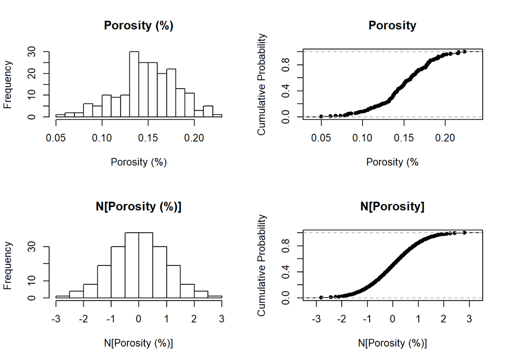

```r
par(mfrow=c(2,2))                              # set up a 2x2 matrix of plots
hist(mydata$porosity,main="Porosity (%)",xlab="Porosity (%)",nclass = 15) # histogram
plot(ecdf(mydata$porosity),main="Porosity",xlab="Porosity (%",ylab="Cumulative Probability") # CDF
hist(mydata$NPorosity,main="N[Porosity (%)]",xlab="N[Porosity (%)]",nclass = 15) # histogram
plot(ecdf(mydata$NPorosity),main="N[Porosity]",xlab="N[Porosity (%)]",ylab="Cumulative Probability") #CDF
```

#### Spatial visualization

It is always good to visualize the data before estimation or simulation to evaluate the spatial arangement of the data. We will look at the general coverage of the data over the area of interest (AOI) (is there clustering or unsampled areas?), degree of continuity and for potential trends. Let’s start with a simple bubble plot. We’ll declare some plotting parameters first. These are simply the color thresholds for the porosity estimates and estimation variance (for kriging) 2D output.

```r
cuts = c(.05,.07,.09,.11,.13,.15,.17,.19,.21,.23)
cuts.var = c(0.05,.1,.15,.20,.25,.3,.35,.4,.45,.5,.55,.6,.65,.7,.75,.8,.85,.9,.95)
```

Now the bubble plot.

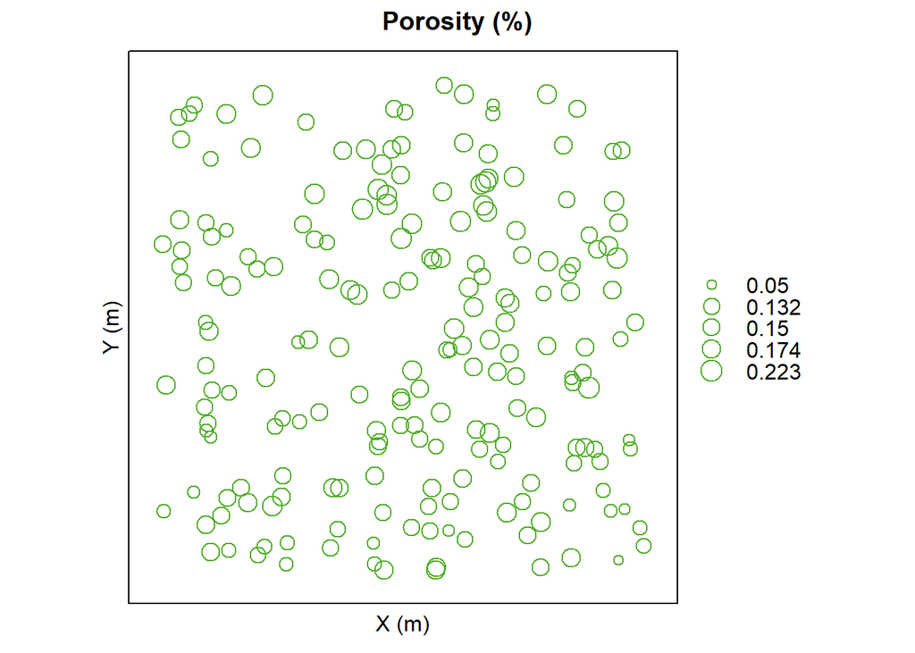

```r
bubble(mydata, "porosity", fill = FALSE, maxsize = 2, main ="Porosity (%)", identify = FALSE,xlab = "X (m)", ylab = "Y (m)")
```

Also, we could review a porosity data location map.

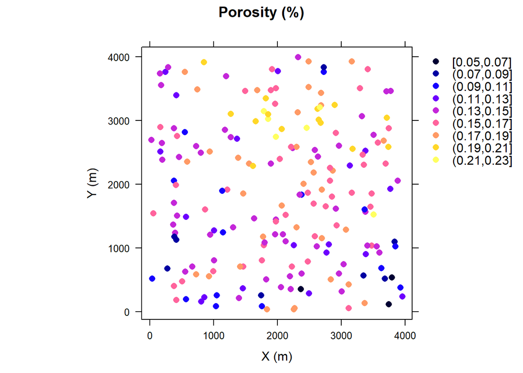

```r
spplot(mydata, "porosity", do.log = TRUE,      # location map of porosity data
       key.space=list(x=1.05,y=0.97,corner=c(0,1)),cuts = cuts,
       scales=list(draw=T),xlab = "X (m)", ylab = "Y (m)",main ="Porosity (%)")
```

#### 2D grid specification

```r
coords <- addcoord(nx,xmin,xsize,ny,ymin,ysize) # make a dataframe with all the estimation locations
summary(coords)                                # check the coordinates
```

```
## Object of class SpatialPoints
## Coordinates:
##   min  max
## X   0 3990
## Y   0 3990
## Is projected: NA
## proj4string : [NA]
## Number of points: 160000
```

#### Variogram modeling

Let’s calculate the key summary statistics from the porosity variable. We will need the minimum and maximum in an 2x1 array to send to the plotting program (image) as the variable color bar limits. We also need the sill ($\sigma_{z}^{2}$ of porosity). Typically we would model the varriogram with a sill of 1.0 for simulation. The simulation program in gstat is coded to not back transform to the original data distribution if the sill is 1.0. The simulation output is standard normal. Therefore we will model to the sill equal to the variance of the data. It is essential that we model to the sill for simulation (the sum of the nest contributions equal the sill), if we model with nested contributions of spatial structures greater than or less than the sill we could create a bias in the distribution variance. We will scale our fractional contributions by the sill from the data variance to make sure we get this right.

```r
sill = var(mydata$porosity)                    # calculate the variance of the property of interest as the sill
min = min(mydata$porosity)                     # calculate the property min and max for plotting
max = max(mydata$porosity)
zlim = c(min,max)                              # define the property min and max in a 2x1 vextor
```

Let’s three variogram models and observe the results. Feel free to change the variogram parameters below. Make sure the fractional contributions of the spherical (psill) and the nugget sum to 1.0 so that the total sill is equal to the variance of the property of interest.

```r
vm.nug1 <- vgm(psill = 0.5*sill, "Sph", 400, anis = c(000, 1.0),nugget=0.5*sill)
vm.nug1
```

```
##   model        psill range
## 1   Nug 0.0005427826     0
## 2   Sph 0.0005427826   400
```

```r
vm.ani1 <- vgm(psill = 1.0*sill, "Exp", 200, anis = c(035, 0.5),nugget=0.0*sill)
vm.ani1
```

```
##   model       psill range ang1 anis1
## 1   Nug 0.000000000     0    0   1.0
## 2   Exp 0.001085565   200   35   0.5
```

```r
vm.ani2 <- vgm(psill = 1.0*sill, "Sph", 600, anis = c(060, 0.2),nugget=0.0*sill)
vm.ani2
```

```
##   model       psill range ang1 anis1
## 1   Nug 0.000000000     0    0   1.0
## 2   Sph 0.001085565   600   60   0.2
```

#### Sequential Gaussian Simulation

Now let’s calculate 4 realizations with each variogram. Note: by setting nsim the krige function switches to simulation with ordinary kriging. If we leave out the nsim parameter the krige function will calculate an ordinary kriging estimation model instead.

```r
condsim.nug1 = krige(porosity~1, mydata, coords, model = vm.nug1, nmax = 100, nsim = 4)
```

```
## drawing 4 GLS realisations of beta...
## [using conditional Gaussian simulation]
```

```r
condsim.ani1 = krige(porosity~1, mydata, coords, model = vm.ani1, nmax = 100, nsim = 4)
```

```
## drawing 4 GLS realisations of beta...
## [using conditional Gaussian simulation]
```

```r
condsim.ani2 = krige(porosity~1, mydata, coords, model = vm.ani2, nmax = 100, nsim = 4)
```

```
## drawing 4 GLS realisations of beta...
## [using conditional Gaussian simulation]
```

The nmax parameter is the maximum number of local data for each kriging or simulation solution. If you omit this parameter then the function will assume infinity. For larger models this will result in very long simulation times due to the sequential addition of data (previously simulated nodes). If your simulations do not reproduce the variogram model then you may need to increase the nmax parameter.

Here’s the four realizations for the first variogram.

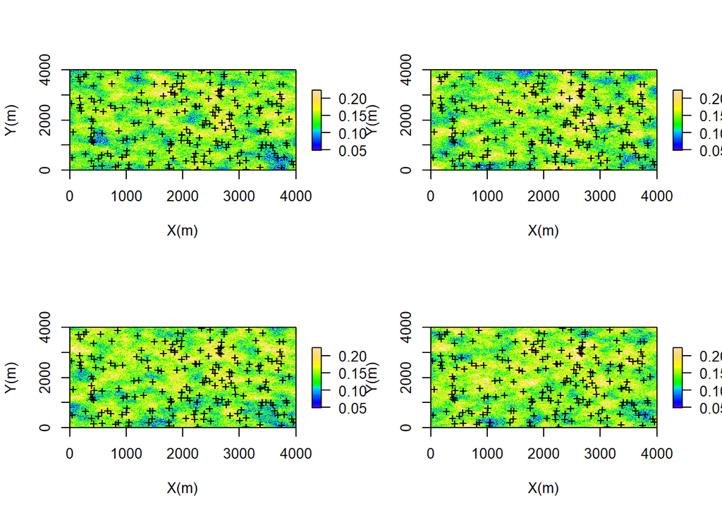

```r
par(mfrow=c(2,2))
real1 <- sim2darray(condsim.nug1,nx,ny,1)      # extract realization #1 to a 2D array and plot
image.plot(real1,x=x,y=y,xlab="X(m)",ylab="Y(m)",zlim = zlim,col=colmap,legend.shrink = 0.6); mtext(line=1, side=3, "Realization #1", outer=F);box(which="plot")
points(mydata$X,mydata$Y,pch="+",cex=1.0,col="black") # add well locations

real2 <- sim2darray(condsim.nug1,nx,ny,2)      # extract realization #2 to a 2D array and plot
image.plot(real2,x=x,y=y,xlab="X(m)",ylab="Y(m)",zlim = zlim,col=colmap,legend.shrink = 0.6); mtext(line=1, side=3, "Realization #2", outer=F);box(which="plot")
points(mydata$X,mydata$Y,pch="+",cex=1.0,col="black") # add well locations

real3 <- sim2darray(condsim.nug1,nx,ny,3)      # extract realization #3 to a 2D array and plot
image.plot(real3,x=x,y=y,xlab="X(m)",ylab="Y(m)",zlim = zlim,col=colmap,legend.shrink = 0.6); mtext(line=1, side=3, "Realization #3", outer=F);box(which="plot")
points(mydata$X,mydata$Y,pch="+",cex=1.0,col="black") # add well locations

real4 <- sim2darray(condsim.nug1,nx,ny,4)      # extract realization #4 to a 2D array and plot
image.plot(real4,x=x,y=y,xlab="X(m)",ylab="Y(m)",zlim = zlim,col=colmap,legend.shrink = 0.6); mtext(line=1, side=3, "Realization #4", outer=F);box(which="plot")
points(mydata$X,mydata$Y,pch="+",cex=1.0,col="black") # add well locations
```

Here’s the four realizations for the second variogram.

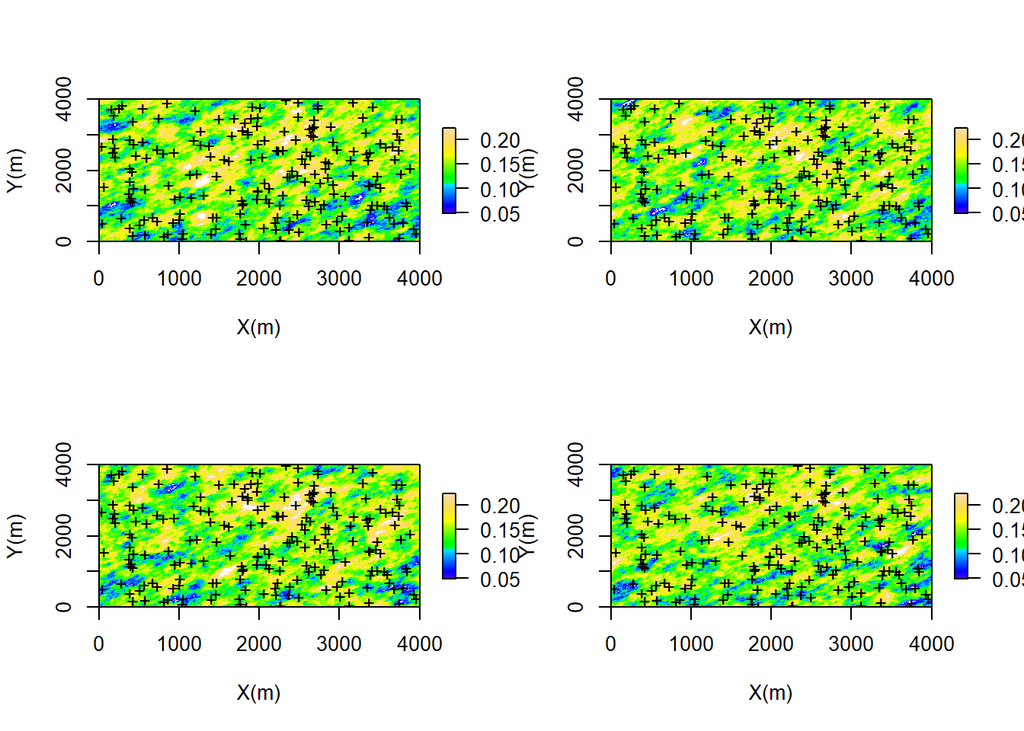

```r
par(mfrow=c(2,2))
real1 <- sim2darray(condsim.ani1,nx,ny,1)      # extract realization #1 to a 2D array and plot
image.plot(real1,x=x,y=y,xlab="X(m)",ylab="Y(m)",zlim = zlim,col=colmap,legend.shrink = 0.6); mtext(line=1, side=3, "Realization #1", outer=F);box(which="plot")
points(mydata$X,mydata$Y,pch="+",cex=1.0,col="black") # add well locations

real2 <- sim2darray(condsim.ani1,nx,ny,2)      # extract realization #2 to a 2D array and plot
image.plot(real2,x=x,y=y,xlab="X(m)",ylab="Y(m)",zlim = zlim,col=colmap,legend.shrink = 0.6); mtext(line=1, side=3, "Realization #2", outer=F);box(which="plot")
points(mydata$X,mydata$Y,pch="+",cex=1.0,col="black") # add well locations

real3 <- sim2darray(condsim.ani1,nx,ny,3)      # extract realization #3 to a 2D array and plot
image.plot(real3,x=x,y=y,xlab="X(m)",ylab="Y(m)",zlim = zlim,col=colmap,legend.shrink = 0.6); mtext(line=1, side=3, "Realization #3", outer=F);box(which="plot")
points(mydata$X,mydata$Y,pch="+",cex=1.0,col="black") # add well locations

real4 <- sim2darray(condsim.ani1,nx,ny,4)      # extract realization #4 to a 2D array and plot
image.plot(real4,x=x,y=y,xlab="X(m)",ylab="Y(m)",zlim = zlim,col=colmap,legend.shrink = 0.6); mtext(line=1, side=3, "Realization #4", outer=F);box(which="plot")
points(mydata$X,mydata$Y,pch="+",cex=1.0,col="black") # add well locations
```

Here’s the four realizations for the third variogram.

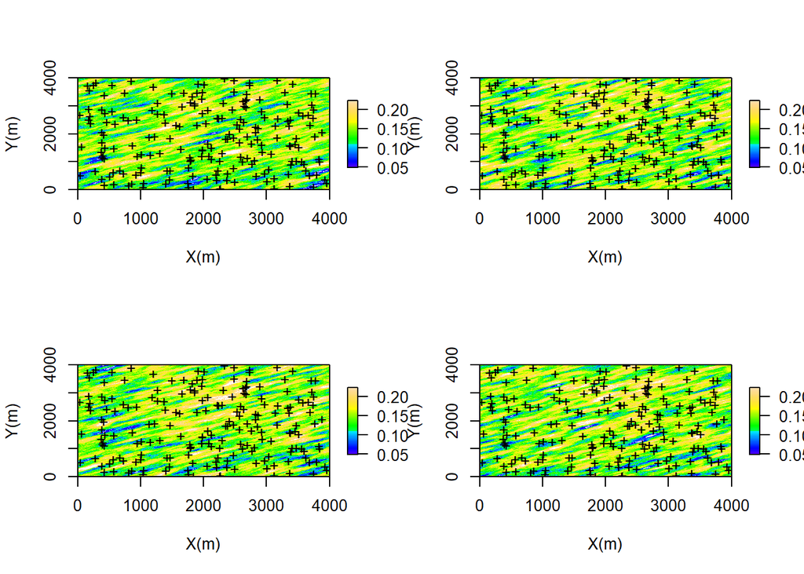

```r
par(mfrow=c(2,2))
real1 <- sim2darray(condsim.ani2,nx,ny,1)      # extract realization #1 to a 2D array and plot
image.plot(real1,x=x,y=y,xlab="X(m)",ylab="Y(m)",zlim = zlim,col=colmap,legend.shrink = 0.6); mtext(line=1, side=3, "Realization #1", outer=F);box(which="plot")
points(mydata$X,mydata$Y,pch="+",cex=1.0,col="black") # add well locations

real2 <- sim2darray(condsim.ani2,nx,ny,2)      # extract realization #2 to a 2D array and plot
image.plot(real2,x=x,y=y,xlab="X(m)",ylab="Y(m)",zlim = zlim,col=colmap,legend.shrink = 0.6); mtext(line=1, side=3, "Realization #2", outer=F);box(which="plot")
points(mydata$X,mydata$Y,pch="+",cex=1.0,col="black") # add well locations

real3 <- sim2darray(condsim.ani2,nx,ny,3)      # extract realization #3 to a 2D array and plot
image.plot(real3,x=x,y=y,xlab="X(m)",ylab="Y(m)",zlim = zlim,col=colmap,legend.shrink = 0.6); mtext(line=1, side=3, "Realization #3", outer=F);box(which="plot")
points(mydata$X,mydata$Y,pch="+",cex=1.0,col="black") # add well locations

real4 <- sim2darray(condsim.ani2,nx,ny,4)      # extract realization #4 to a 2D array and plot
image.plot(real4,x=x,y=y,xlab="X(m)",ylab="Y(m)",zlim = zlim,col=colmap,legend.shrink = 0.6); mtext(line=1, side=3, "Realization #4", outer=F);box(which="plot")
points(mydata$X,mydata$Y,pch="+",cex=1.0,col="black") # add well locations
```

There is a paper by Leuangthong, McLennan and Deutsch (2004) on the miminum acceptance criteria for geostatistical realizations. The authors suggest checking the realization distributions (CDFs) and spatial continuity (vairograms). Let’s calculate the realization CDFs and variograms and compare with the model inputs.

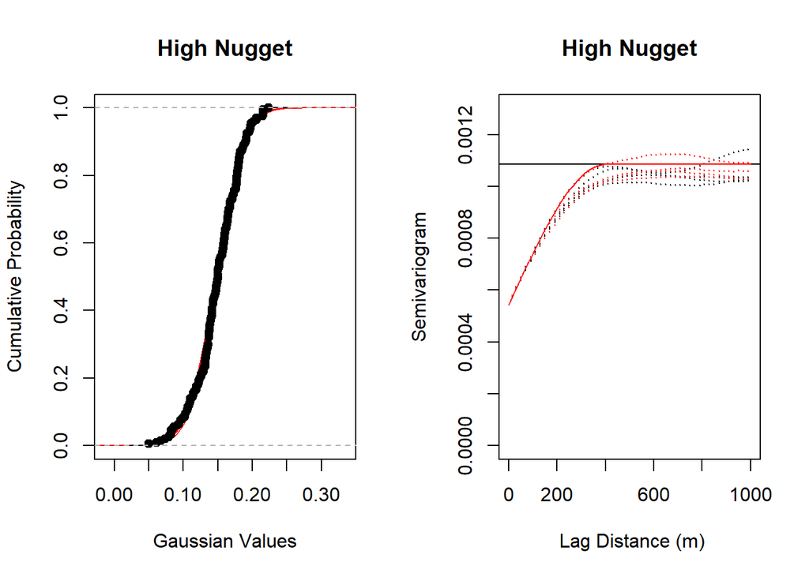

```r
# First variogram model
par(mfrow=c(1,2))
# Plot the CDFs for the 4 realizations and compare to the raw data CDF
plot(ecdf(condsim.nug1@data[,1]),main="High Nugget",xlab="Gaussian Values",ylab="Cumulative Probability",col="red")
plot(ecdf(condsim.nug1@data[,2]),add=TRUE,col="red")
plot(ecdf(condsim.nug1@data[,3]),add=TRUE,col="red")
plot(ecdf(condsim.nug1@data[,4]),add=TRUE,col="red")
plot(ecdf(mydata$porosity),add=TRUE,col="black")

# Calculate the varograms for the major and minor directions and compare to the variogram model
# We just arbitrarily picked 035, 125 azimuth, model is isotropic so direction shouldn't matter
vg.sim1.035 = variogram(sim1~1,condsim.nug1,cutoff = 1000,width =20,alpha = 35.0,tol.hor=22.5)
vg.sim1.125 = variogram(sim1~1,condsim.nug1,cutoff = 1000,width =20,alpha = 125.0,tol.hor=22.5)
vg.sim2.035 = variogram(sim2~1,condsim.nug1,cutoff = 1000,width =20,alpha = 35.0,tol.hor=22.5)
vg.sim2.125 = variogram(sim2~1,condsim.nug1,cutoff = 1000,width =20,alpha = 125.0,tol.hor=22.5)
vg.sim3.035 = variogram(sim3~1,condsim.nug1,cutoff = 1000,width =20,alpha = 35.0,tol.hor=22.5)
vg.sim3.125 = variogram(sim3~1,condsim.nug1,cutoff = 1000,width =20,alpha = 125.0,tol.hor=22.5)
vg.sim4.035 = variogram(sim4~1,condsim.nug1,cutoff = 1000,width =20,alpha = 35.0,tol.hor=22.5)
vg.sim4.125 = variogram(sim4~1,condsim.nug1,cutoff = 1000,width =20,alpha = 125.0,tol.hor=22.5)

# Plot the vairograms from the realizations and the model variogram.
plot(vg.sim1.035$dist,vg.sim1.035$gamma,pch=19,cex=0.1,main="High Nugget",xlab="  Lag Distance (m) ",ylab=" Semivariogram ", col="black",xlim=c(0,1000),ylim=c(0,1.2*sill))
points(vg.sim1.125$dist,vg.sim1.125$gamma,pch=19,cex=0.1,col="red")
points(vg.sim2.035$dist,vg.sim2.035$gamma,pch=19,cex=0.1,col="black")
points(vg.sim2.125$dist,vg.sim2.125$gamma,pch=19,cex=0.1,col="red")
points(vg.sim3.035$dist,vg.sim3.035$gamma,pch=19,cex=0.1,col="black")
points(vg.sim3.125$dist,vg.sim3.125$gamma,pch=19,cex=0.1,col="red")
points(vg.sim4.035$dist,vg.sim4.035$gamma,pch=19,cex=0.1,col="black")
points(vg.sim4.125$dist,vg.sim4.125$gamma,pch=19,cex=0.1,col="red")
abline(h = 1.0*sill)
# Include variogram model
unit_vector = c(0,1,0)                         # unit vector for 000 azimuth
vm.nug1.000 <- variogramLine(vm.nug1,maxdist=1000,min=0.0001,n=100,dir=unit_vector,covariance=FALSE) # calculate 035 variogram model
lines(vm.nug1.000$dist,vm.nug1.000$gamma,pch=19,cex=0.1,col="black") # include variogram model
unit_vector = c(1,0,0)                         # unit vector for 090 azimuth
vm.ani.090 <- variogramLine(vm.nug1,maxdist=1000,min=0.0001,n=100,dir=unit_vector,covariance=FALSE) # calculate 125 variogram model
lines(vm.ani.090$dist,vm.ani.090$gamma,col="red")
```

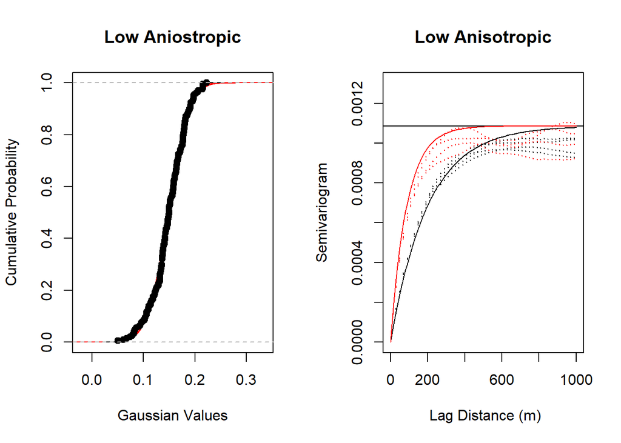

```r
# Second variogram model
par(mfrow=c(1,2))
# Plot the CDFs for the 4 realizations and compare to the raw data CDF
plot(ecdf(condsim.ani1@data[,1]),main="Low Aniostropic",xlab="Gaussian Values",ylab="Cumulative Probability",col="red")
plot(ecdf(condsim.ani1@data[,2]),add=TRUE,col="red")
plot(ecdf(condsim.ani1@data[,3]),add=TRUE,col="red")
plot(ecdf(condsim.ani1@data[,4]),add=TRUE,col="red")
plot(ecdf(mydata$porosity),add=TRUE,col="black")

vg.sim1.035 = variogram(sim1~1,condsim.ani1,cutoff = 1000,width =20,alpha = 35.0,tol.hor=22.5)
vg.sim1.125 = variogram(sim1~1,condsim.ani1,cutoff = 1000,width =20,alpha = 125.0,tol.hor=22.5)
vg.sim2.035 = variogram(sim2~1,condsim.ani1,cutoff = 1000,width =20,alpha = 35.0,tol.hor=22.5)
vg.sim2.125 = variogram(sim2~1,condsim.ani1,cutoff = 1000,width =20,alpha = 125.0,tol.hor=22.5)
vg.sim3.035 = variogram(sim3~1,condsim.ani1,cutoff = 1000,width =20,alpha = 35.0,tol.hor=22.5)
vg.sim3.125 = variogram(sim3~1,condsim.ani1,cutoff = 1000,width =20,alpha = 125.0,tol.hor=22.5)
vg.sim4.035 = variogram(sim4~1,condsim.ani1,cutoff = 1000,width =20,alpha = 35.0,tol.hor=22.5)
vg.sim4.125 = variogram(sim4~1,condsim.ani1,cutoff = 1000,width =20,alpha = 125.0,tol.hor=22.5)

plot(vg.sim1.035$dist,vg.sim1.035$gamma,pch=19,cex=0.1,main="Low Anisotropic",xlab="  Lag Distance (m) ",ylab=" Semivariogram ", col="black",xlim=c(0,1000),ylim=c(0,1.2*sill))
points(vg.sim1.125$dist,vg.sim1.125$gamma,pch=19,cex=0.1,col="red")
points(vg.sim2.035$dist,vg.sim2.035$gamma,pch=19,cex=0.1,col="black")
points(vg.sim2.125$dist,vg.sim2.125$gamma,pch=19,cex=0.1,col="red")
points(vg.sim3.035$dist,vg.sim3.035$gamma,pch=19,cex=0.1,col="black")
points(vg.sim3.125$dist,vg.sim3.125$gamma,pch=19,cex=0.1,col="red")
points(vg.sim4.035$dist,vg.sim4.035$gamma,pch=19,cex=0.1,col="black")
points(vg.sim4.125$dist,vg.sim4.125$gamma,pch=19,cex=0.1,col="red")
abline(h = 1.0*sill)
# Include variogram model
unit_vector = c(sin(35*pi/180),cos(35*pi/180),0) # unit vector for 035 azimuth
vm.nug1.035 <- variogramLine(vm.ani1,maxdist=1000,min=0.0001,n=100,dir=unit_vector,covariance=FALSE) # calculate 035 variogram model
lines(vm.nug1.035$dist,vm.nug1.035$gamma,pch=19,cex=0.1,col="black") # include variogram model

unit_vector = c(sin(55*pi/180),-1*cos(35*pi/180),0) # unit vector for 125 azimuth
vm.ani.125 <- variogramLine(vm.ani1,maxdist=1000,min=0.0001,n=100,dir=unit_vector,covariance=FALSE) # calculate 125 variogram model
lines(vm.ani.125$dist,vm.ani.125$gamma,col="red") # include variogram model
```

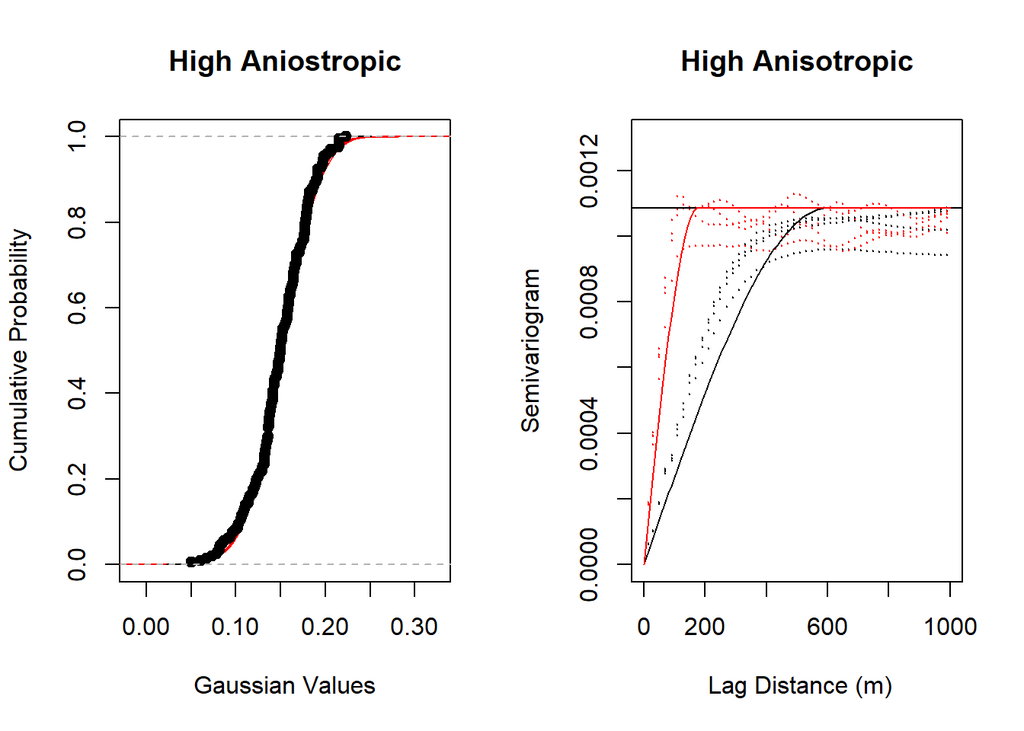

```r
# Third variogram model
par(mfrow=c(1,2))
# Plot the CDFs for the 4 realizations and compare to the raw data CDF
plot(ecdf(condsim.ani2@data[,1]),main="High Aniostropic",xlab="Gaussian Values",ylab="Cumulative Probability",col="red")
plot(ecdf(condsim.ani2@data[,2]),add=TRUE,col="red")
plot(ecdf(condsim.ani2@data[,3]),add=TRUE,col="red")
plot(ecdf(condsim.ani2@data[,4]),add=TRUE,col="red")
plot(ecdf(mydata$porosity),add=TRUE,col="black")

vg.sim1.060 = variogram(sim1~1,condsim.ani2,cutoff = 1000,width =20,alpha = 60.0,tol.hor=22.5)
vg.sim1.150 = variogram(sim1~1,condsim.ani2,cutoff = 1000,width =20,alpha = 150.0,tol.hor=22.5)
vg.sim2.060 = variogram(sim2~1,condsim.ani2,cutoff = 1000,width =20,alpha = 60.0,tol.hor=22.5)
vg.sim2.150 = variogram(sim2~1,condsim.ani2,cutoff = 1000,width =20,alpha = 150.0,tol.hor=22.5)
vg.sim3.060 = variogram(sim3~1,condsim.ani2,cutoff = 1000,width =20,alpha = 60.0,tol.hor=22.5)
vg.sim3.150 = variogram(sim3~1,condsim.ani2,cutoff = 1000,width =20,alpha = 150.0,tol.hor=22.5)
vg.sim4.060 = variogram(sim4~1,condsim.ani2,cutoff = 1000,width =20,alpha = 60.0,tol.hor=22.5)
vg.sim4.150 = variogram(sim4~1,condsim.ani2,cutoff = 1000,width =20,alpha = 150.0,tol.hor=22.5)

plot(vg.sim1.060$dist,vg.sim1.060$gamma,pch=19,cex=0.1,main="High Anisotropic",xlab="  Lag Distance (m) ",ylab=" Semivariogram ", col="black",xlim=c(0,1000),ylim=c(0,1.2*sill))
points(vg.sim1.150$dist,vg.sim1.150$gamma,pch=19,cex=0.1,col="red")
points(vg.sim2.060$dist,vg.sim2.060$gamma,pch=19,cex=0.1,col="black")
points(vg.sim2.150$dist,vg.sim2.150$gamma,pch=19,cex=0.1,col="red")
points(vg.sim3.060$dist,vg.sim3.060$gamma,pch=19,cex=0.1,col="black")
points(vg.sim3.150$dist,vg.sim3.150$gamma,pch=19,cex=0.1,col="red")
points(vg.sim4.060$dist,vg.sim4.060$gamma,pch=19,cex=0.1,col="black")
points(vg.sim4.150$dist,vg.sim4.150$gamma,pch=19,cex=0.1,col="red")
abline(h = 1.0*sill)
# Include variogram model
unit_vector = c(sin(60*pi/180),cos(60*pi/180),0) # unit vector for 060 azimuth
vm.nug1.060 <- variogramLine(vm.ani2,maxdist=1000,min=0.0001,n=100,dir=unit_vector,covariance=FALSE) # calculate 035 variogram model
lines(vm.nug1.060$dist,vm.nug1.060$gamma,pch=19,cex=0.1,col="black") # include variogram model

unit_vector = c(sin(30*pi/180),-1*cos(60*pi/180),0) # unit vector for 125 azimuth
vm.ani.150 <- variogramLine(vm.ani2,maxdist=1000,min=0.0001,n=100,dir=unit_vector,covariance=FALSE) # calculate 125 variogram model
lines(vm.ani.150$dist,vm.ani.150$gamma,col="red") # include variogram model
```

There are so many more tests that one could attempt to gain experience with of spatial simulaton. I’ll end here for brevity, but invite you to continue. Consider, on your own continue changing the variogram parameters and observe the results. Make the variogram range large relative to the model size and observe the ergodic fluctuations in the CDFs and variograms. Also attempt kriging with a trend.

I hope you found this tutorial useful. I’m always happy to discuss geostatistics, statistical modeling, uncertainty modeling and machine learning,

Michael Pyrcz, Ph.D., P.Eng.

Associate Professor

The Hildebrand Department of Petroleum and Geosystems Engineering

The University of Texas at Austin